# Group Predictions

6

10

8

11

7

0.5000

5

0.5526

0.5526

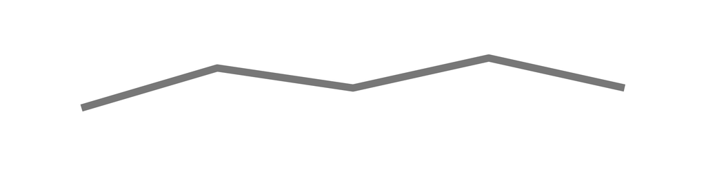

Min Choi

6

7

9

11

7

0.5000

5

0.5263

0.5263

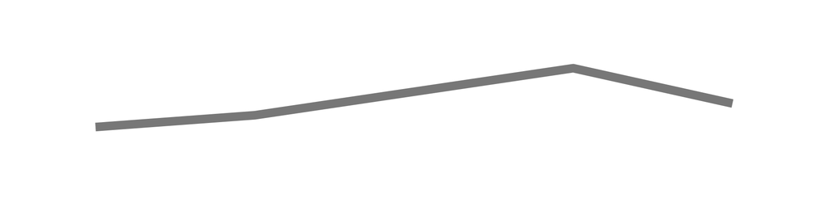

Ryan Cvik

11

11

9

13

6

0.4286

5

0.6579

0.6579

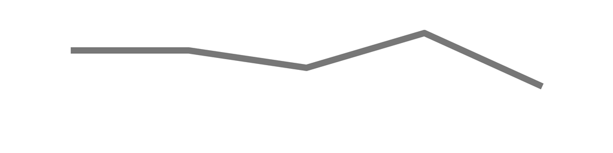

Gabriel Quinones

9

11

12

12

6

0.4286

5

0.6579

0.6579

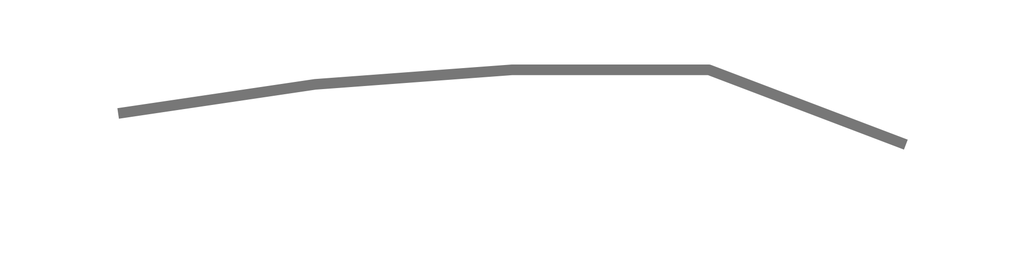

Cheryl Brown

10

12

11

9

6

0.4286

5

0.6316

0.6316

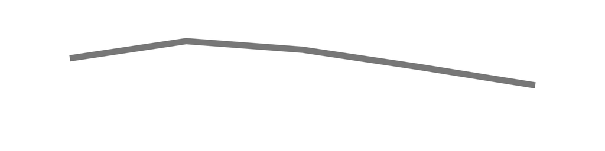

Kristen White

7

13

8

11

6

0.4286

5

0.5921

0.5921

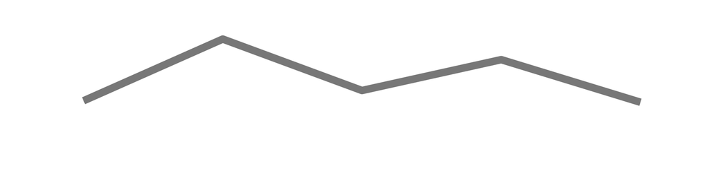

William Sherman

8

11

10

10

6

0.4286

5

0.5921

0.5921

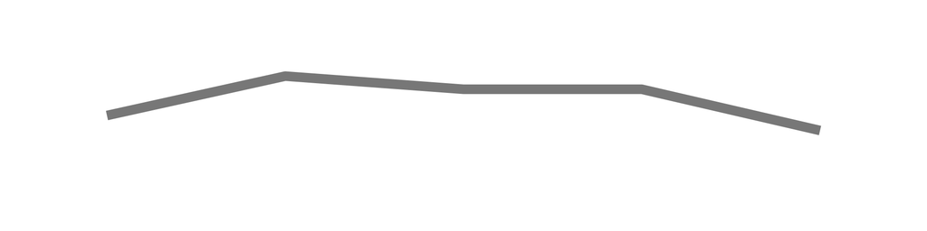

Pamela AUGUSTINE

11

13

6

9

6

0.4286

5

0.5921

0.5921

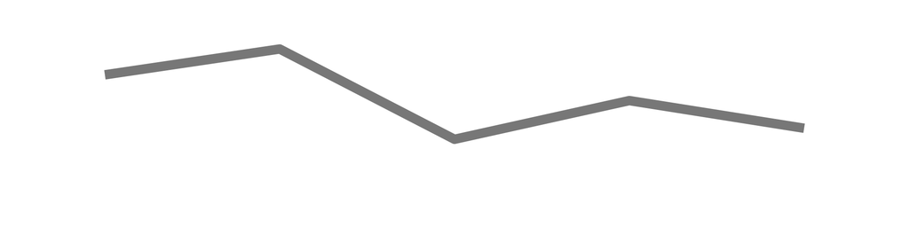

Trevor MACGAVIN

6

10

8

NA

6

0.4286

4

0.5000

0.4000

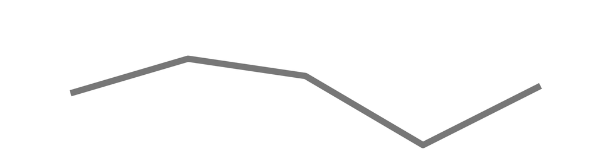

Derrick Zantt

11

6

7

NA

6

0.4286

4

0.5000

0.4000

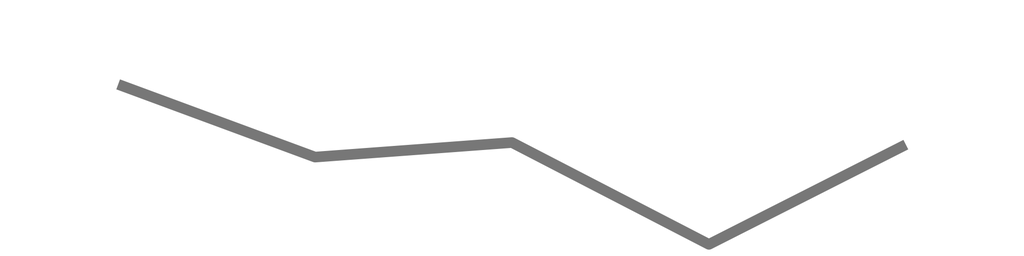

Ryan Shipley

3

8

7

6

6

0.4286

5

0.3947

0.3947

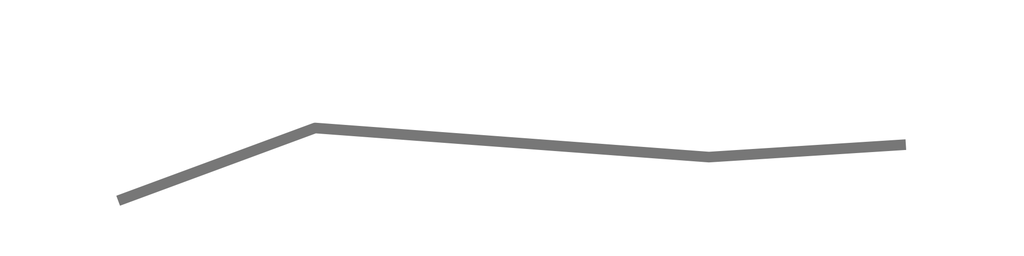

Earl Dixon

9

11

8

12

5

0.3571

5

0.5921

0.5921

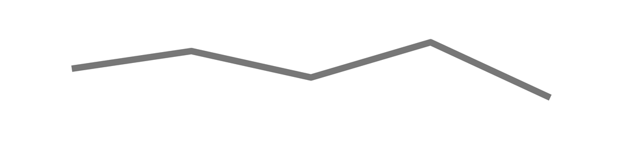

Alexander Santillan

5

NA

8

9

5

0.3571

4

0.4500

0.3600

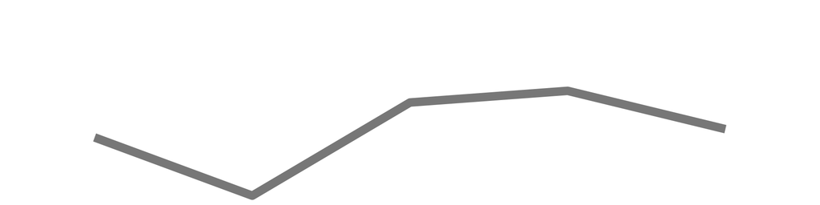

James Blejski

8

11

10

14

NA

0.0000

4

0.6935

0.5548

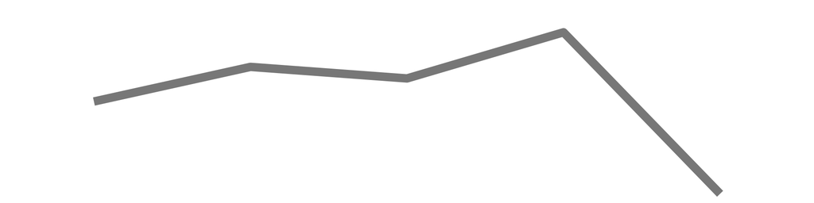

Michael Edmunds

10

12

10

10

NA

0.0000

4

0.6774

0.5419

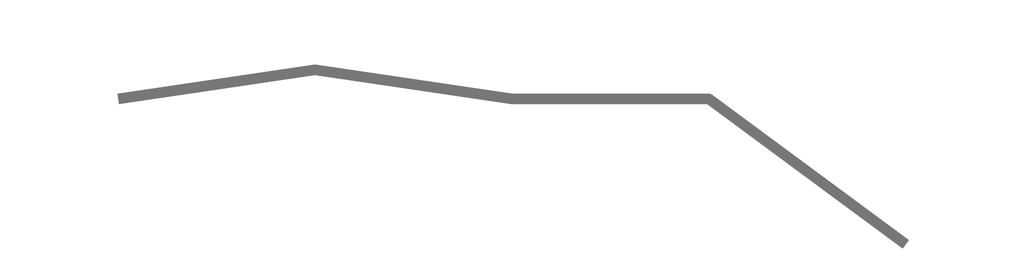

Stephen Woolwine

8

13

9

NA

NA

0.0000

3

0.6522

0.3913

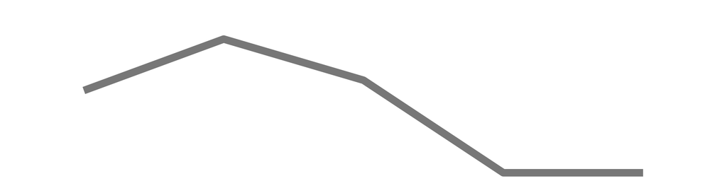

David Spielman

8

NA

11

NA

NA

0.0000

2

0.6333

0.2533

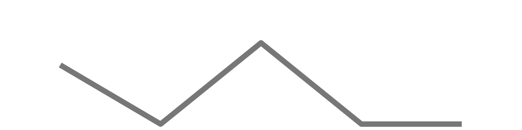

Carlos Caceres

10

NA

NA

NA

NA

0.0000

1

0.6250

0.1250

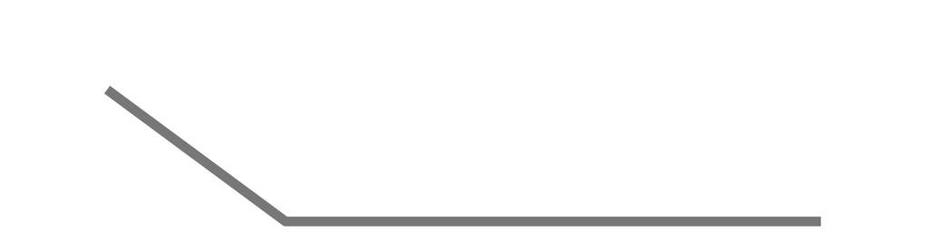

John Plaster

8

12

8

10

NA

0.0000

4

0.6129

0.4903

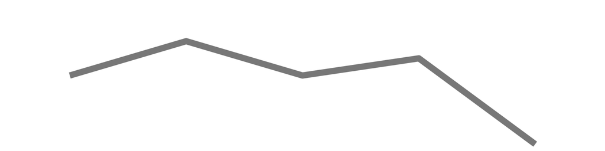

Rafael Torres